# Programme for International Student Assessment (PISA)

## by (Haitham Essam)

## Investigation Overview

In this investigation, I am interested to know what makes the student gets high marks with the least effort and what is the role of student and teacher.

## Dataset Overview

The data consists of information regarding 48,5490 students, including grade, srudent's mindset, teacher's role, facilities and other properties. The dataset can be found [here](https://www.google.com/url?q=https://s3.amazonaws.com/udacity-hosted-downloads/ud507/pisa2012.csv.zip&sa=D&ust=1611166993106000&usg=AOvVaw2584P2MKVx610FBqEiZvDp) with it's dictionary [here](https://www.google.com/url?q=https://s3.amazonaws.com/udacity-hosted-downloads/ud507/pisadict2012.csv&sa=D&ust=1611166993108000&usg=AOvVaw27_q_LEUoTD8Vqte3EpVkB) with feature documentation available [here](http://www.oecd.org/pisa/aboutpisa/pisa-2012-participants.htm), [here](http://www.oecd.org/pisa/pisaproducts/datavisualizationcontest.htm) and [here](http://www.oecd.org/pisa/data/pisa2012technicalreport.htm)

## Student studying with parents

Students don't study much time with parents max 2 hours, as if we draw the barchar we wil see that two hours will get the first place by more than 210,000.

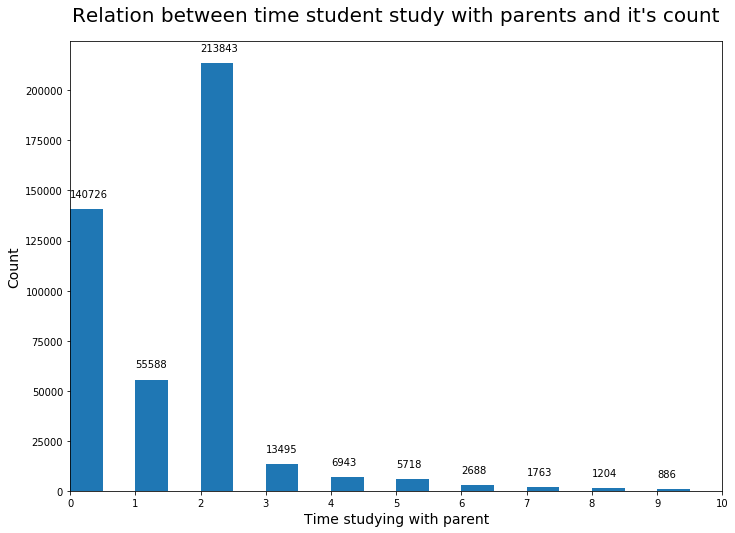

## Student with computer

Most of them don't spend much time on computer to study max 2 hours, also two hours get the first place by more than 210,000.

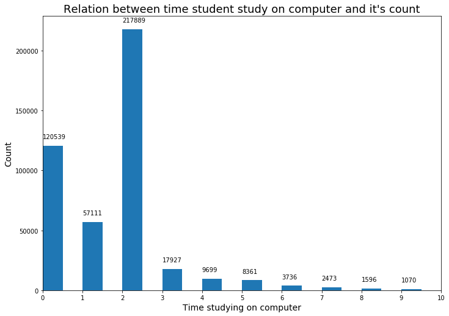

## Student and study time

Six hour for studying is a popular time, if we look at the next barchar we will see average or most studying time density from 0.1 to 0.2 but six hours got more than 0.8 which make it very popular.

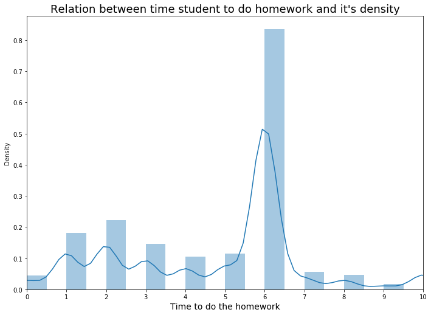

## Students studying the homework

Student spends less hour in the guided homework, as most popular hour in guided homework is two hours which is less than home work which is six.

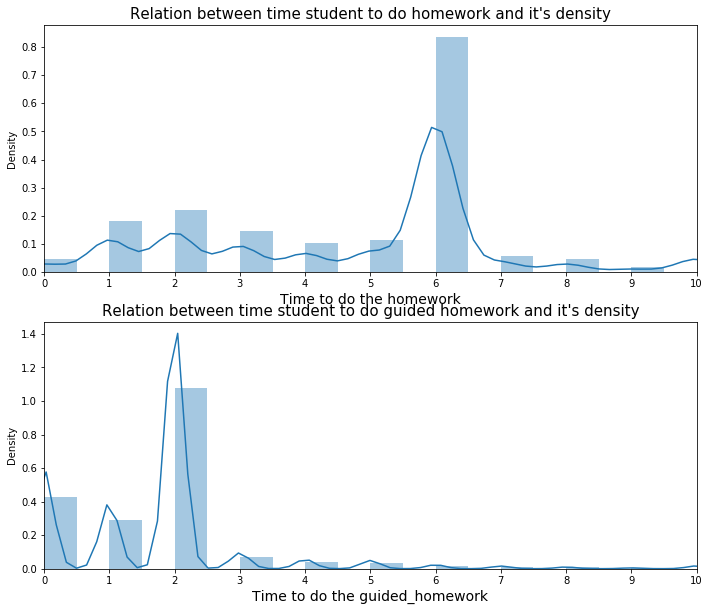

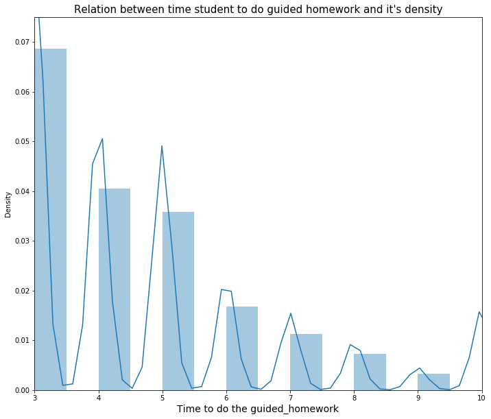

## Believes and grades

Believes affects the grades. Good believes and self confident lead to high grades and bad believes leads to poor grades

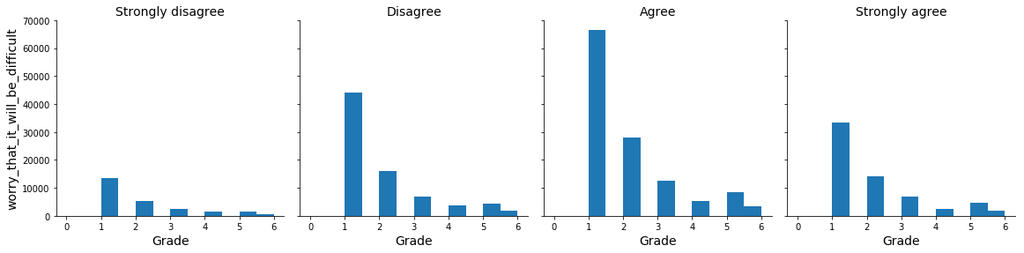

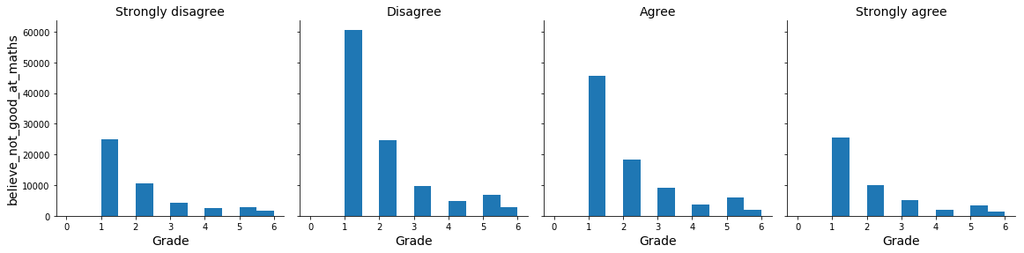

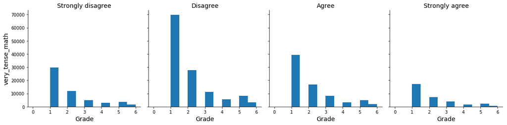

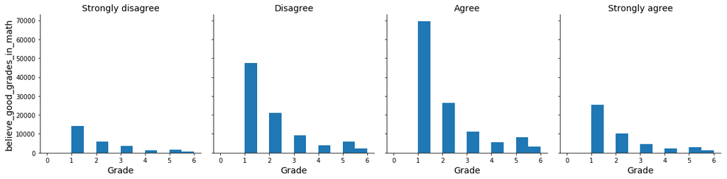

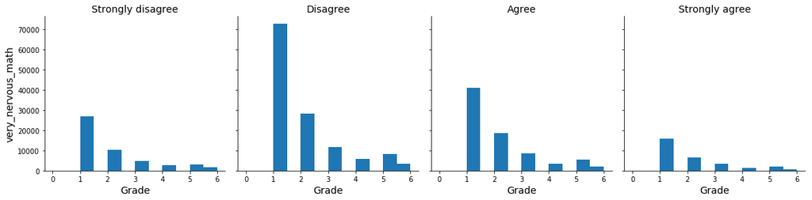

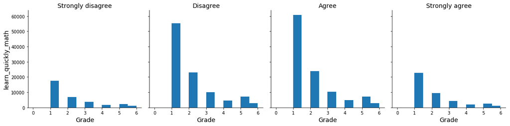

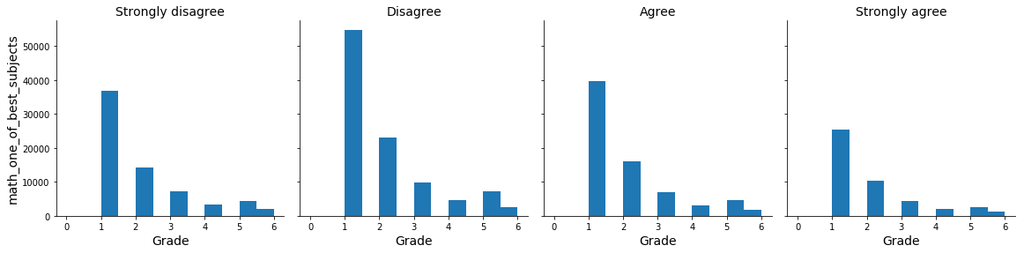

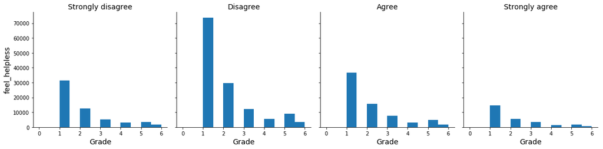

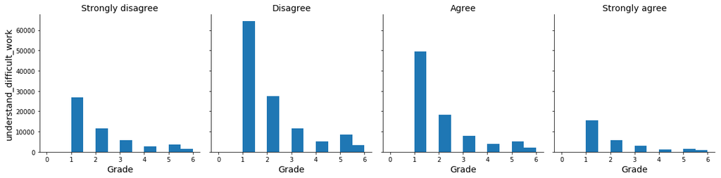

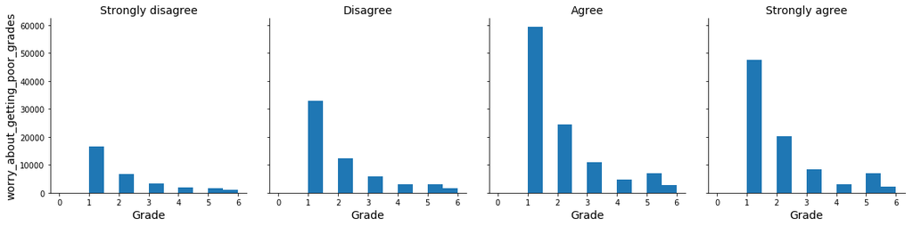

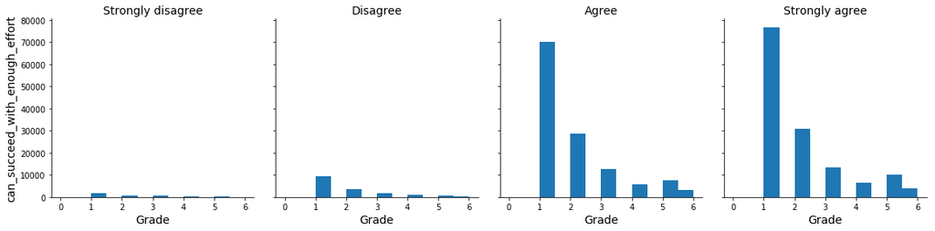

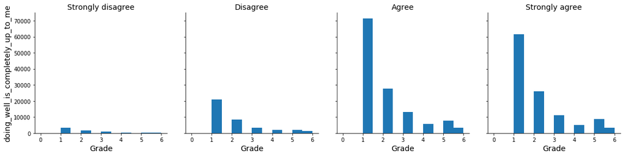

[4 more figures not shown]

## Effort and grades

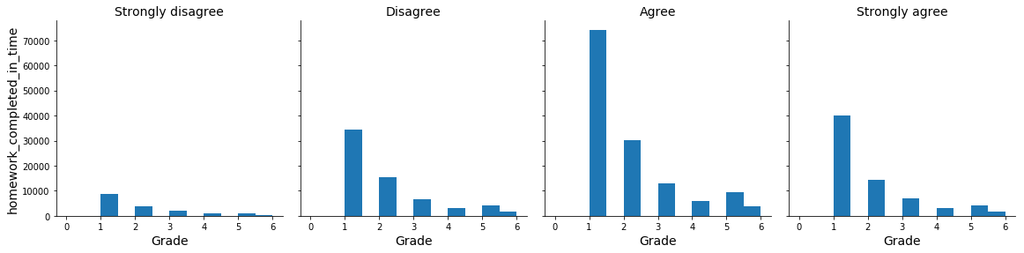

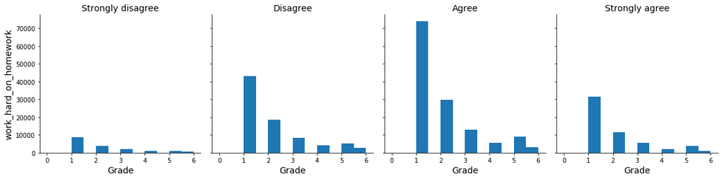

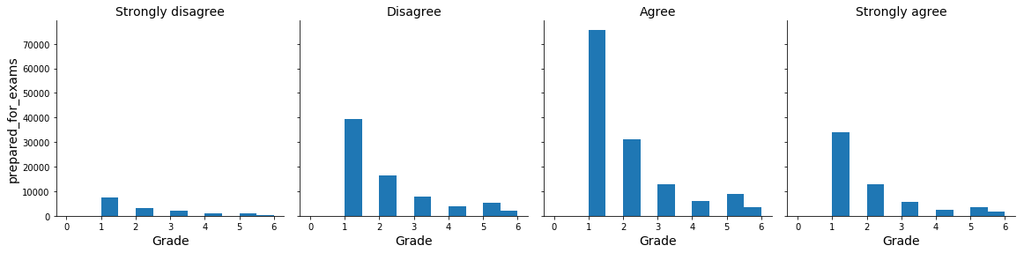

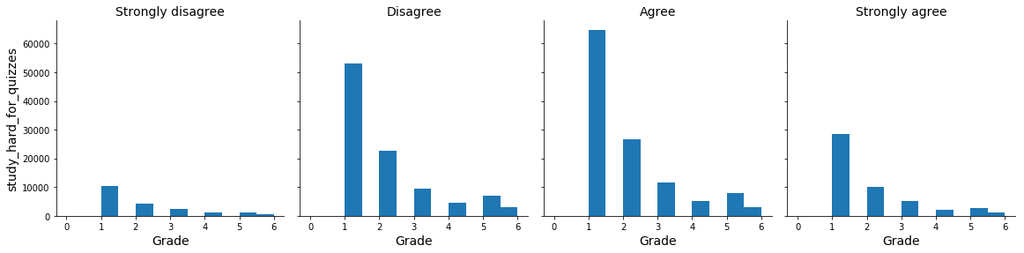

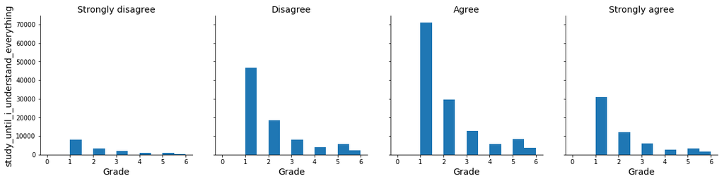

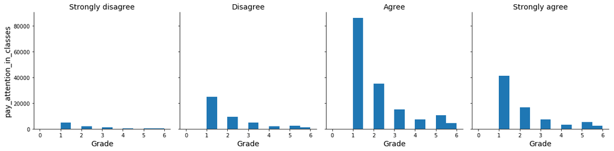

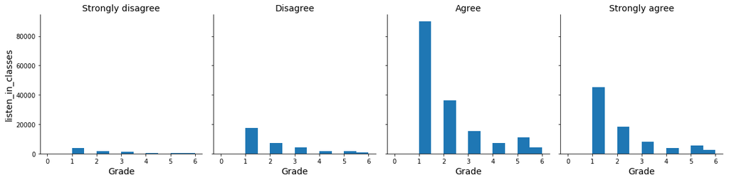

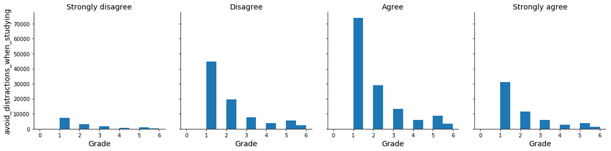

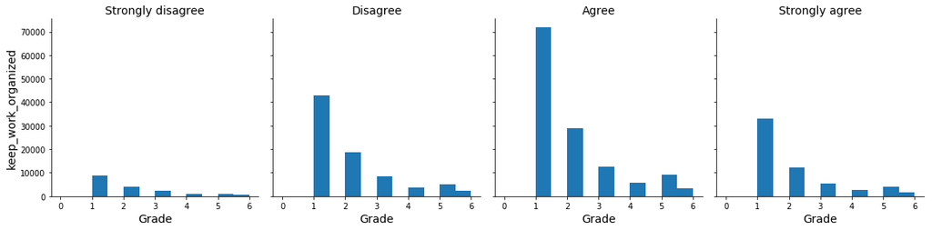

## Psychology and grades

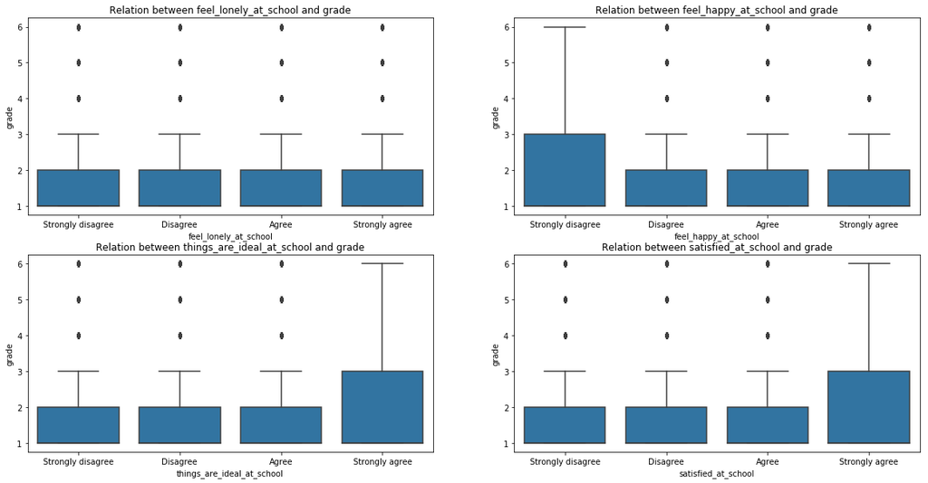

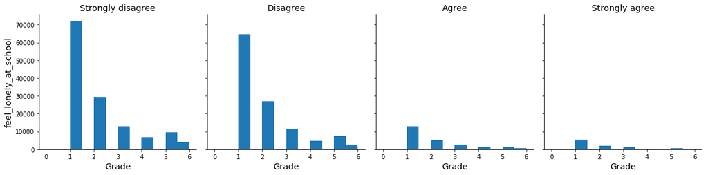

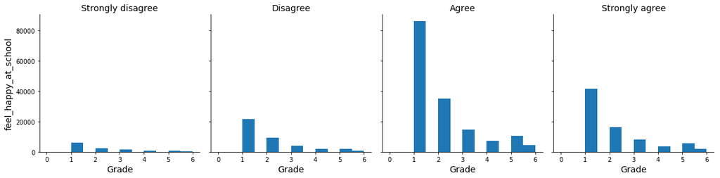

[figure not shown]

## Parents and grades

Parents beliefs affects students grades. When parents think this subject is important or they just they like it the student's grade increases.

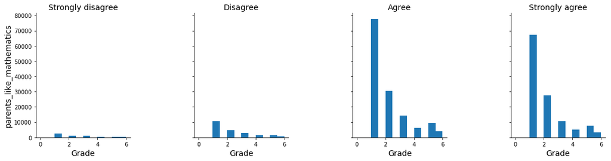

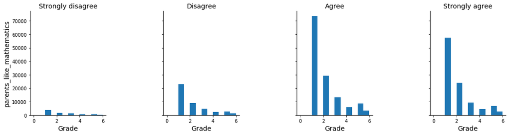

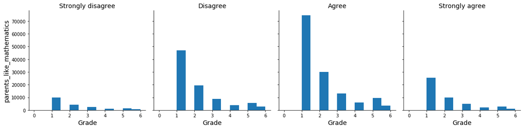